# shRNA positions associated with changes in mRNA stability in ENCODE RBP KD samples

Gabrielle Perron

2026-September-24

# 1 Load libraries

```r
library(Biostrings)
library(data.table)
library(gplots)
```

# 2 Load shRNA sequences file

```r
RNAi_seqs <- read.table(here("data", "RNAi_sequences.txt"), header = T)

# Format the Experiment names appropriately
RNAi_seqs$Experiment <- gsub("/experiments/", "", RNAi_seqs$Experiment)
RNAi_seqs$Experiment <- gsub("/", "", RNAi_seqs$Experiment)

# Format the shRNA sequence appropriately
RNAi_seqs$RNAi_sequence <- gsub("-", "", RNAi_seqs$RNAi_sequence)
```

# 3 Load the 3’UTR sequences

```r
UTR_seq <- as.character(readDNAStringSet(here("data", "3UTR_seq.fa")))
names(UTR_seq) <- gsub(".*gene=", "", names(UTR_seq))
```

# 4 Trim to keep the first 2000bps of each 3’UTR

```r
UTR_seq <- unlist(lapply(UTR_seq, function(x) substring(x, 1, 2000)))
```

# 5 Load bias and batch corrected stability estimates

```r
stab_HepG2 <- read.csv(here("ENCODE_RBP_KD", "output", "supplementary_tables", "ENCODE_RBP_KD_bias_batch_corrected_stability_HepG2.csv"), row.names=1)
stab_K562 <- read.csv(here("ENCODE_RBP_KD", "output", "supplementary_tables", "ENCODE_RBP_KD_bias_batch_corrected_stability_K562.csv"), row.names=1)
```

# 6 Filter stability and UTR sequences tables to keep the same genes in the same order

```r
common_genes_HepG2 <- intersect(row.names(stab_HepG2), names(UTR_seq))
common_genes_K562 <- intersect(row.names(stab_K562), names(UTR_seq))

UTR_HepG2_fltr <- UTR_seq[common_genes_HepG2]
stab_HepG2_fltr <- stab_HepG2[common_genes_HepG2, ]

UTR_K562_fltr <- UTR_seq[common_genes_K562]
stab_K562_fltr <- stab_K562[common_genes_K562, ]
```

# 7 Test associations between counts of shRNA 6-mers/7-mers in 3’UTRs and mRNA stability

For each cell line, for each sample (and so for each shRNA), use a 6nt/7nt-length sliding window to get all 6nt/7nt sequences in the shRNA and count their occurrence in the 3’UTRs. Then we assess the associations between counts of shRNA 6-mers/7-mers in 3’UTRs and mRNA stability (bias- and batch-corrected). We do this separately for 6-mers and 7-mers. Retain regression coefficients and P-values

```r
# Helper function to reverse-complement shRNA sequence to obtain the genomic target sequence
revComp <- function(seq) {
  as.character(reverseComplement(DNAString(seq)))
}

# Helper function to count kmers efficiently across all genes at once
count_kmers <- function(subject, kmers) {

  counts_mat <- sapply(kmers, function(kmer) {
    vcountPattern(
      pattern = kmer,
      subject = subject,
      fixed = TRUE
    )
  })

  if (is.vector(counts_mat)) {
    counts_mat <- matrix(counts_mat, ncol = 1)
  }

  rownames(counts_mat) <- names(subject)
  colnames(counts_mat) <- kmers

  counts_mat
}

# Helper function to generate k-mers from shRNA and count them in UTRs
# Returns k-mer counts for all positions in the shRNA (including duplicates)
generate_kmer_counts <- function(shRNA, UTRs_dna, kmer_len, revComp) {
  # Generate k-mers using sliding window
  n <- nchar(shRNA)
  mers <- substring(shRNA, 1:(n - kmer_len + 1), kmer_len:n)

  # Reverse complement to get target sequences
  mers <- unlist(lapply(mers, revComp))

  # Track unique k-mers (for regression fitting)
  dup_mask <- duplicated(mers)
  unique_mers <- mers[!dup_mask]

  # Count occurrences in UTRs
  counts_unique <- count_kmers(UTRs_dna, unique_mers)

  # Restore counts for all positions including duplicates
  counts_all <- counts_unique[, match(mers, unique_mers), drop = FALSE]
  colnames(counts_all) <- NULL  # Remove column names as they're position-based

  list(
    mers_all = mers,
    mers_unique = unique_mers,
    counts_unique = counts_unique,
    counts_all = counts_all
  )
}

# Storage for regression results and k-mer counts
regression_results <- list()
kmer_counts <- list()

# Testing associations between 6/7-mer counts and mRNA stability
for(len in c(6, 7)) {
  regression_results[[paste0("len_", len)]] <- list()
  kmer_counts[[paste0("len_", len)]] <- list()

  for (cell in c("HepG2", "K562")) {
    # UTR sequences for the cell line
    UTRs <- switch(cell, HepG2 = UTR_HepG2_fltr, K562 = UTR_K562_fltr)
    UTRs_dna <- DNAStringSet(UTRs)
    names(UTRs_dna) <- names(UTRs)

    # Stability data for the cell line
    stab <- switch(cell, HepG2 = stab_HepG2_fltr, K562 = stab_K562_fltr)

    # For each sample
    for(i in seq_len(ncol(stab))) {
      # Define the experiment
      experiment <- gsub("_.*", "", colnames(stab)[i])

      # Skip if experiment not in shRNA sequences table
      if (!(experiment %in% RNAi_seqs$Experiment)) {
        next
      }

      # Get shRNA and generate k-mer counts
      shRNA <- RNAi_seqs[RNAi_seqs$Experiment == experiment, ]$RNAi_sequence
      if(length(shRNA)!=1){
        stop("Expected one shRNA for experiment ", experiment)
      }

      kmer_data <- generate_kmer_counts(shRNA, UTRs_dna, len, revComp)

      # Validation: ensure no k-mers are absent from all UTRs
      if (sum(colSums(kmer_data$counts_unique) == 0) > 0) {
        stop("ERROR: some k-mers don't occur in any UTR(s)")
      }

      # Fit regression using unique k-mer counts (avoids multicollinearity)
      fit <- lm(stab[, i] ~ data.matrix(kmer_data$counts_unique), na.action = na.exclude)

      # Extract and restore coefficients/p-values for all positions
      fit_summary <- coef(summary(fit))
      coeffs_unique <- fit_summary[-1, "Estimate"]
      pvals_unique <- fit_summary[-1, "Pr(>|t|)"]

      # Match back to all positions (including duplicates)
      coeffs_all <- coeffs_unique[match(kmer_data$mers_all, kmer_data$mers_unique)]
      pvals_all <- pvals_unique[match(kmer_data$mers_all, kmer_data$mers_unique)]

      sample_name <- colnames(stab)[i]

      # Store regression results
      regression_results[[paste0("len_", len)]][[sample_name]] <- list(
        coeffs = coeffs_all,
        pvals = pvals_all
      )

      # Store k-mer counts for later use in stability correction
      kmer_counts[[paste0("len_", len)]][[sample_name]] <- kmer_data$counts_all
    }
  }
}

saveRDS(regression_results, here("ENCODE_RBP_KD", "output", "rds", "regression_results.rds"))
# saveRDS(kmer_counts, here("ENCODE_RBP_KD", "output", "rds", "kmer_counts.rds"))
```

# 8 Visualize the shRNA positions most strongly associated with mRNA stability

We visualize which shRNA positions (1-54) are most predictive of mRNA stability changes.

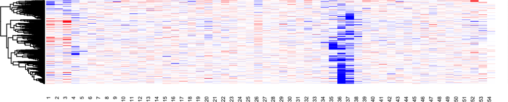

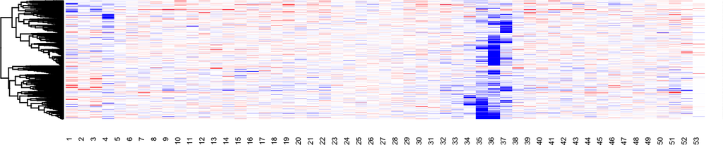

```r
for(len in c(6, 7)) {
  # Extract regression results for the kmer length
  results_key <- paste0("len_", len)
  sample_results <- regression_results[[results_key]]

  # Get all sample names and determine max shRNA length
  sample_names <- names(sample_results)
  max_len <- max(sapply(sample_results, function(x) length(x$coeffs)))

  # Initialize matrices for all coefficients and p-values
  coeffs <- matrix(0, nrow = length(sample_names), ncol = max_len)
  pvals <- matrix(0, nrow = length(sample_names), ncol = max_len)
  rownames(coeffs) <- sample_names
  rownames(pvals) <- sample_names
  colnames(coeffs) <- as.character(1:max_len)
  colnames(pvals) <- as.character(1:max_len)

  # Pad shorter shRNAs with zeros so all samples share a common matrix dimension
  for (i in seq_along(sample_names)) {
    sample_name <- sample_names[i]
    coeff_vec <- sample_results[[sample_name]]$coeffs
    pval_vec <- sample_results[[sample_name]]$pvals

    coeffs[i, 1:length(coeff_vec)] <- coeff_vec
    pvals[i, 1:length(pval_vec)] <- pval_vec
  }

  # Compute signed log10(p-values) with direction from coefficients
  signs <- sign(coeffs)
  slog10pvals <- abs(log10(pvals)) * signs
  slog10pvals[is.na(slog10pvals)] <- 0

  # Generate heatmap
  palette <- colorRampPalette(c("blue", "white", "red"))
  tryCatch({
    heatmap.2(slog10pvals, trace = "none", col = palette, cexRow = 0.001, cexCol = 0.5,
              breaks = seq(-10, 10, length.out = 100), mar = c(2, 2), key = FALSE, Colv = FALSE,
              hclust = function(x) hclust(x, method = "complete"),
              distfun = function(x) as.dist((1 - cor(t(x))) / 2),
              density.info = "none", lwid = c(1, 10))
    pdf(here("ENCODE_RBP_KD", "output", "figures",
             paste("ENCODE_RBP_KD_shRNA_", len, "mers_positions_vsStab_signedlog10pvals.pdf", sep="")),
        height = 2, width = 7)
    heatmap.2(slog10pvals, trace = "none", col = palette, cexRow = 0.001, cexCol = 0.5,
              breaks = seq(-10, 10, length.out = 100), mar = c(2, 2), key = FALSE, Colv = FALSE,
              hclust = function(x) hclust(x, method = "complete"),
              distfun = function(x) as.dist((1 - cor(t(x))) / 2),
              density.info = "none", lwid = c(1, 10))
    dev.off()
  }, error = function(e) {})
}
```

# 9 Identify positions of shRNAs that are predictive of stability changes (Fisher’s exact test)

- Multiple testing corrections for P-values obtained at step 1
- Filter for significant hits
- For each shRNA position, determine if there are more significant hits than expected by chance (Fisher’s test)
- Repeat for 6-mers and 7-mers separately

```r
# Helper function to identify significant positions using Fisher's exact test
identify_sig_positions <- function(FDR_mat) {
  # Convert FDR matrix to binary (sig = 1, not sig = 0), preserving matrix structure
  FDR_bin <- matrix(as.integer(FDR_mat < 0.05), nrow = nrow(FDR_mat))
  FDR_bin[is.na(FDR_mat)] <- 0

  # For each position, run Fisher's test: is this position enriched for significant hits?
  n_pos <- ncol(FDR_bin)
  fisher_results <- data.frame(
    position = seq_len(n_pos),
    p_value = numeric(n_pos),
    odds_ratio = numeric(n_pos)
  )

  for (pos in seq_len(n_pos)) {
    # Contingency table: [sig at pos, sig elsewhere | not sig at pos, not sig elsewhere]
    sig_at_pos <- sum(FDR_bin[, pos] == 1)
    sig_elsewhere <- sum(FDR_bin[, -pos] == 1)
    not_sig_at_pos <- sum(FDR_bin[, pos] == 0)
    not_sig_elsewhere <- sum(FDR_bin[, -pos] == 0)

    cont_tbl <- matrix(c(sig_at_pos, sig_elsewhere, not_sig_at_pos, not_sig_elsewhere), nrow = 2)
    test_result <- fisher.test(cont_tbl)

    fisher_results$p_value[pos] <- test_result$p.value
    fisher_results$odds_ratio[pos] <- test_result$estimate
  }

  # Return positions with significant enrichment (p < 0.05 AND odds ratio > 1)
  fisher_results$position[fisher_results$p_value < 0.05 & fisher_results$odds_ratio > 1]
}

# Helper function to extract p-values from regression_results and prepare for FDR correction
extract_pvals_FDR_corr <- function(regression_results, len) {
  # Extract p-values for the specified k-mer length from regression_results
  results_key <- paste0("len_", len)
  sample_results <- regression_results[[results_key]]

  # Extract p-value vectors from each sample
  pvals_data <- lapply(sample_results, function(x) x$pvals)

  # Pad to equal length
  max_len <- max(lengths(pvals_data))
  pvals_data <- lapply(pvals_data, function(x) {
    c(x, rep(NA, max_len - length(x)))
  })

  # Combine into matrix
  pvals_matrix <- do.call(rbind, pvals_data)

  # Apply FDR correction across entire matrix
  pvals_vector <- c(pvals_matrix)
  pvals_fdr <- p.adjust(pvals_vector, method = "fdr")
  matrix(pvals_fdr, nrow = nrow(pvals_matrix), ncol = ncol(pvals_matrix))
}

# Process 6-mers
FDR_6mers <- extract_pvals_FDR_corr(regression_results, 6)
sig_pos_6mers <- identify_sig_positions(FDR_6mers)
sig_pos_6mers
```

```
## [1]  1  3  4 35 36 37 38
```

```r
# Process 7-mers
FDR_7mers <- extract_pvals_FDR_corr(regression_results, 7)
sig_pos_7mers <- identify_sig_positions(FDR_7mers)
sig_pos_7mers
```

```
## [1]  1  3  4 34 35 36 37
```

# 10 Correct stability estimates for shRNA off-target effects

Using a regression with 6-mer and 7-mer counts from the positions associated with off-target effects as predictors, retain residuals as corrected stability data

```r
# Helper function to correct stability estimates using significant k-mer positions (associated with off-target effects)
correct_stability <- function(stab, kmer_counts_6, kmer_counts_7, sig_pos_6mers, sig_pos_7mers) {
  # Initialize the corrected stability matrix
  corr_stab <- matrix(NA, nrow = nrow(stab), ncol = ncol(stab))
  rownames(corr_stab) <- rownames(stab)
  colnames(corr_stab) <- colnames(stab)

  for (i in seq_len(ncol(stab))) {
    sample_name <- colnames(stab)[i]

    # Skip if no k-mer counts available for this sample
    if (!(sample_name %in% names(kmer_counts_6))) {
      next
    }

    # Extract counts for significant positions and merge
    counts_6 <- kmer_counts_6[[sample_name]][, sig_pos_6mers, drop = FALSE]
    counts_7 <- kmer_counts_7[[sample_name]][, sig_pos_7mers, drop = FALSE]
    counts_merged <- cbind(counts_6, counts_7)

    # Skip if no significant positions found for this sample
    if (ncol(counts_merged) == 0) {
      next
    }

    # Remove duplicate columns (can occur if different positions have identical k-mers)
    dup_cols <- duplicated(t(counts_merged))
    if (any(dup_cols)) {
      warning(paste("Sample", sample_name, ": Removing", sum(dup_cols), "duplicate column(s)"))
      counts_merged <- counts_merged[, !dup_cols, drop = FALSE]
    }

    # Verify gene ordering matches
    if (!all(rownames(counts_merged) == rownames(stab))) {
      stop(paste("Gene order mismatch for sample", sample_name))
    }

    # Fit regression and extract residuals as corrected stability
    fit <- lm(stab[, i] ~ data.matrix(counts_merged), na.action = na.exclude)
    corr_stab[, i] <- residuals(fit)
  }

  corr_stab
}

# Generate corrected stability matrices
corr_stab_HepG2 <- correct_stability(
  stab_HepG2_fltr,
  kmer_counts$len_6,
  kmer_counts$len_7,
  sig_pos_6mers,
  sig_pos_7mers
)

corr_stab_K562 <- correct_stability(
  stab_K562_fltr,
  kmer_counts$len_6,
  kmer_counts$len_7,
  sig_pos_6mers,
  sig_pos_7mers
)

# Remove samples with all NAs (i.e., no valid k-mer counts)
corr_stab_HepG2 <- corr_stab_HepG2[, colSums(is.na(corr_stab_HepG2)) < nrow(corr_stab_HepG2)]
corr_stab_K562 <- corr_stab_K562[, colSums(is.na(corr_stab_K562)) < nrow(corr_stab_K562)]

# Save corrected stability estimates
write.csv(corr_stab_HepG2, file = here("ENCODE_RBP_KD", "output", "supplementary_tables", "ENCODE_RBP_KD_stab_corr_bias_batch_shRNAoffTargetEffects_HepG2.csv"))
write.csv(corr_stab_K562, file = here("ENCODE_RBP_KD", "output", "supplementary_tables", "ENCODE_RBP_KD_stab_corr_bias_batch_shRNAoffTargetEffects_K562.csv"))
```